# Práctica 2

Técnicas de predicción de series temporales

Guillermo González Díaz

12/11/2021

# Librerias

```r
library(tidyverse)
library(tsibble)
library(feasts)
library(TSA)
library(Hmisc)
library(astsa)
library(dynlm)
library(tsoutliers)
library(xts)
library(forecast)
library(urca)
library(tseries)
```

# Lectura de datos:

Leemos nuestra data y creamos un df con las dos series juntas. Función ts para crear una serie temporal. Dividimos nuestras dos series temporales:

```r
df <- read_csv("../practica_2/colgate_crest.csv")
colgate <- ts(df$Colgate, start = c(1958, 1), frequency = 52.18)
crest <- ts(df$Crest, start = c(1958, 1), frequency = 52.18)
data <- cbind(colgate, crest)
```

# Plots

Dibujamos nuestras series temporales. Usamos autoplot, que es como ggplot con series temporales, sin necesidad de decirle que se trata de una serie temporal.

Vemos que existe TENDENCIA en ambas series y en sentidos contrarios, siendo crest de tendencia creciente y colgate de tendencia decreciente.

```
Plot variable not specified, automatically selected `.vars = value`
```

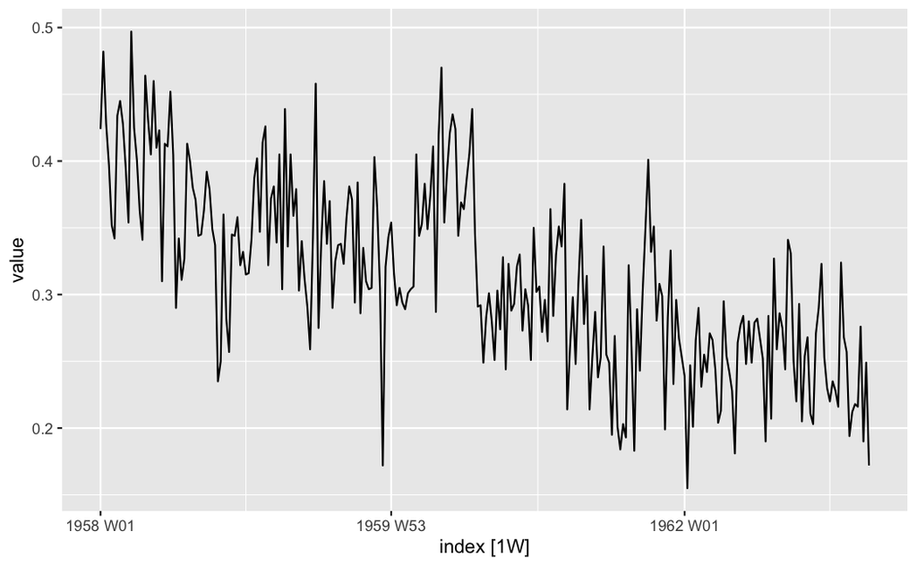

```r
autoplot(as_tsibble(colgate))
```

```
Plot variable not specified, automatically selected `.vars = value`
```

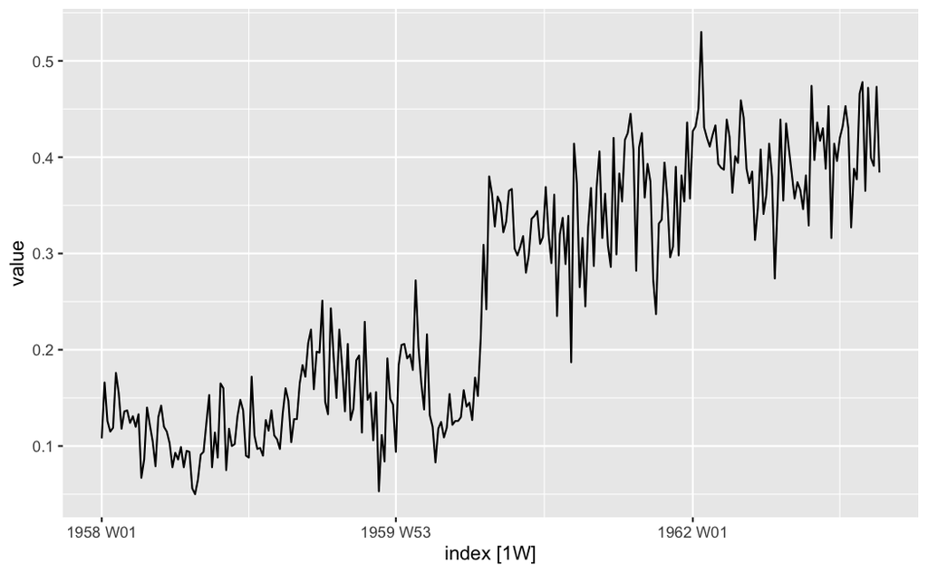

```r
autoplot(as_tsibble(crest))
```

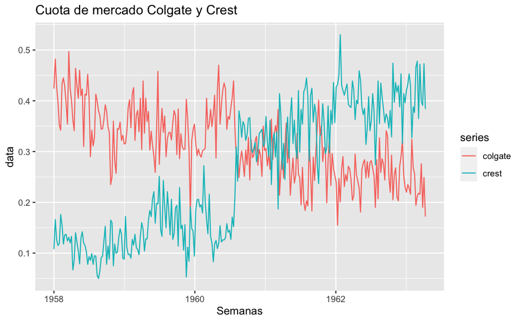

```r
autoplot(data)+
  labs(title = "Cuota de mercado Colgate y Crest",
       x="Semanas")
```

# Train/Test split

A continuación dividimos nuestra muestra con train y test: Para ello, en el train nos quedamos con todas las semanas menos las 16 últimas, y en el tes con las 16 últimas:

```r
ts_colgate_train <- head(colgate, length(colgate) - 16)
ts_crest_train <- head(crest, length(crest) - 16)

ts_colgate_test <- tail(colgate, 16)
ts_crest_test <- tail(crest, 16)

ts_data_train <- cbind(ts_colgate_train, ts_crest_train)
ts_data_test <- cbind(ts_colgate_test, ts_crest_test)

autoplot(ts_colgate_train) + autolayer(ts_colgate_test)
autoplot(ts_crest_train) + autolayer(ts_crest_test)
```

[output not shown]

A continuación pasamos a realizar nuestros modelos ARIMA. Ruido blanco significa que nuestro modelo se ajusta bien cuando la media es igual a cero, la varainza es constante y no está serialmente correlacionada. Si esto ocurre decimos que hay ruido blanco y nuestro modelo se ajusta bien.

# Dickie-Fuller

Realizamos los test corresponientes para comprobar la estacionariedad de neustras series. Una vez que hemos comprobado que las series son esatcionarias, podemos pasar a realizar nuestro modelo ARIMA.

```r
adf.test(ts_crest_train, alternative = "stationary")
```

```
    Augmented Dickey-Fuller Test

data:  ts_crest_train
Dickey-Fuller = -3.4939, Lag order = 6, p-value = 0.04382
alternative hypothesis: stationary
```

# Correlacion:

Queremos ver la función de autocorrelación y la función de autocorrelación parcial. Con estas medidas sabremos cuantas medias móviles y cuantos autoregresivos vamos a utilizar en nuestro modelo ARIMA. ACF (función de autocorrelación) y PCF (función de autocorrelación parcial) son los comandos que usaremos.

PACF nos dice el numero de autoregresivos, y ACF el de medias móviles.

[figure not shown]

# Arima Colgate

Lo ejecutamos con 4 autoregresivos, 0 diferencias y 1 media móvil.

Muy importante aquí, no hacerlo sobre nuestra serie diferida, sino sobre la ORIGINAL. Cuando imprimimos el modelo, podemos ver los coeficientes para nuestros autoregresivos: ar1, ar2, ar3, ar4 y para nuestra media móvil, ma1. Debajo de ello, los errores estándar.

```r
arima_colgate <- arima(ts_colgate_train, order = c(4, 0, 1))
arima_colgate
```

```
Call:
arima(x = ts_colgate_train, order = c(4, 0, 1))

Coefficients:
         ar1      ar2      ar3     ar4      ma1  intercept
      1.0564  -0.0726  -0.0223  0.0183  -0.7685     0.3236
s.e.  0.1360   0.0967   0.0917  0.0839   0.1224     0.0295

sigma^2 estimated as 0.002272:  log likelihood = 421.75,  aic = -831.5
```

# Arima Crest

```r
arima_crest <- arima(ts_crest_train, order = c(2, 0, 1))
arima_crest
```

[output not shown]

# Ljung Box Test

```r
tsdiag(arima_colgate)
Box.test(residuals(arima_colgate), type = "Ljung-Box")
```

[output not shown]

# Error

Vamos a comprobar que la media del error se aproxima a 0.

```r
error_colgate=residuals(arima_colgate)
plot(error_colgate)
```

[output not shown]

# Autoarima Colgate

Autoarima is a really usefull model to do forecast in the short-term.

```r
aut_colg <- auto.arima(ts_colgate_train,lambda=0)
summary(aut_colg)
```

[output not shown]